# ECON320Lec_HW3

D.Z.

05 January 2020

## Part 1

1. Generate a dataset of 100,000 observations from this DGP. Call this the “population data”

```r
x <- rnorm(100000, 10, 10)
u <- rnorm(100000, 0, 5)
y = 2.5 + 1.5 * x + u
population_data <- data.frame(x, u, y)
```

2. Draw a random sample of 1,000 observations from the population data. Estimate the parameters $\beta_0$ and $\beta_1$.

```r
randX1000 <- sample_n(population_data, 1000)
randX1000Reg <- lm(formula = y ~ x, data = randX1000)
summary(randX1000Reg)
```

```
##
## Call:
## lm(formula = y ~ x, data = randX1000)
##
## Residuals:
##      Min       1Q   Median       3Q      Max
## -16.8619  -3.4771  -0.0808   3.3404  17.6121
##
## Coefficients:
##             Estimate Std. Error t value Pr(>|t|)
## (Intercept)  2.62421    0.24081   10.90   <2e-16 ***
## x            1.49358    0.01702   87.74   <2e-16 ***
## ---
## Signif. codes:  0 '***' 0.001 '**' 0.01 '*' 0.05 '.' 0.1 ' ' 1
##
## Residual standard error: 5.197 on 998 degrees of freedom
## Multiple R-squared:  0.8852, Adjusted R-squared:  0.8851
## F-statistic:  7698 on 1 and 998 DF,  p-value: < 2.2e-16
```

```r
(beta_0 <- summary(randX1000Reg)$coefficients[1, 1])
```

```
## [1] 2.62421
```

```r
(beta_1 <- summary(randX1000Reg)$coefficients[2, 1])
```

```
## [1] 1.493584
```

3. Repeat step ii. 1000 times, and save the estimated parameters from each draw

```r
beta_0_vector <- c()
beta_1_vector <- c()
for(i in 1:1000) {
  newPop <- population_data[sample(nrow(population_data), 1000), ]
  beta_0 <- mean(newPop$y) - mean(newPop$x) * beta_1
  beta_1 <- cov(newPop$y, newPop$x) / var(newPop$x)
  beta_0_vector <- c(beta_0_vector, beta_0)
  beta_1_vector <- c(beta_1_vector, beta_1)
}
```

4. Present histograms of the sampling distribution of the estimates of $\beta_0$ and $\beta_1$. Call these Figures 1 and 2 (with appropriate titles).

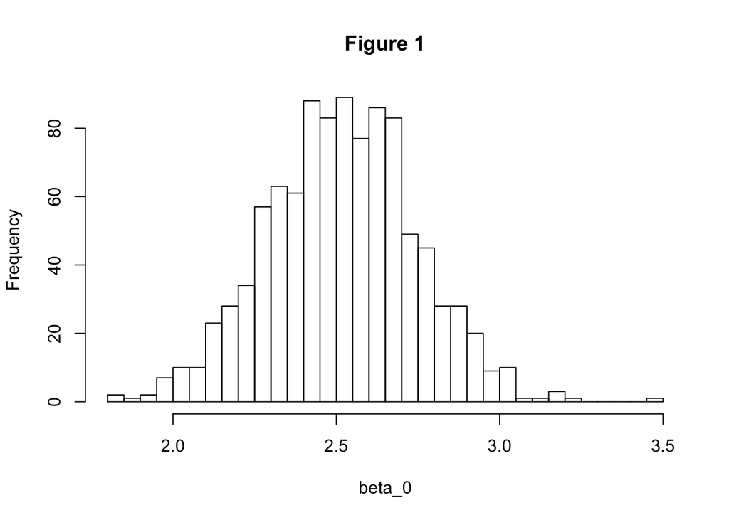

```r
hist(beta_0_vector, main = "Figure 1", xlab = "beta_0", breaks = 30)
```

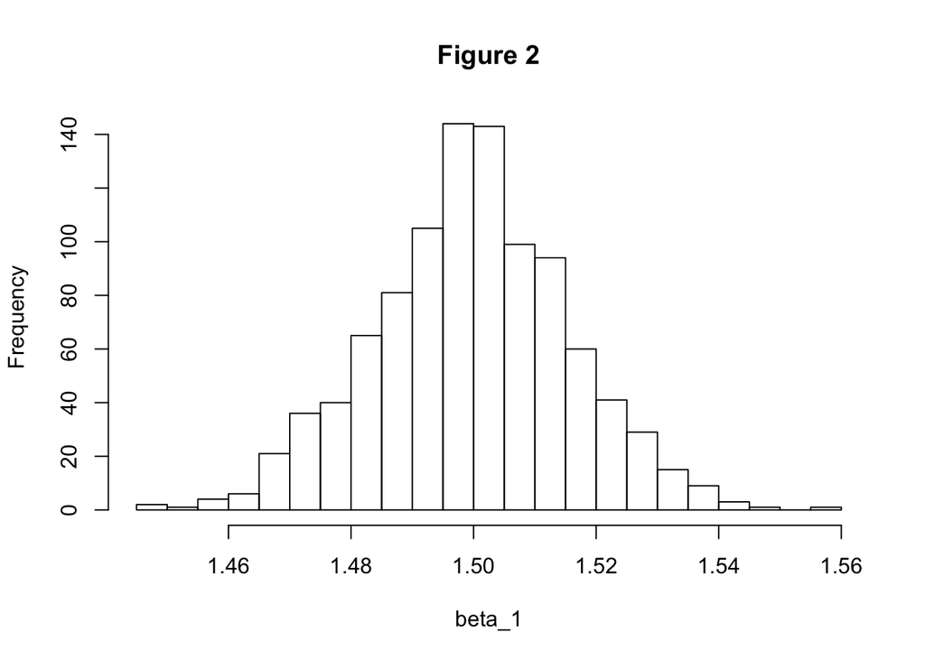

```r
hist(beta_1_vector, main = "Figure 2", xlab = "beta_1", breaks = 30)
```

22. What happens to the sampling distributions of the estimate of $\beta_1$ if U ~ N(0, 50) or U ~ N(0, 1)? Present two more histograms, Figures 3 and 4.

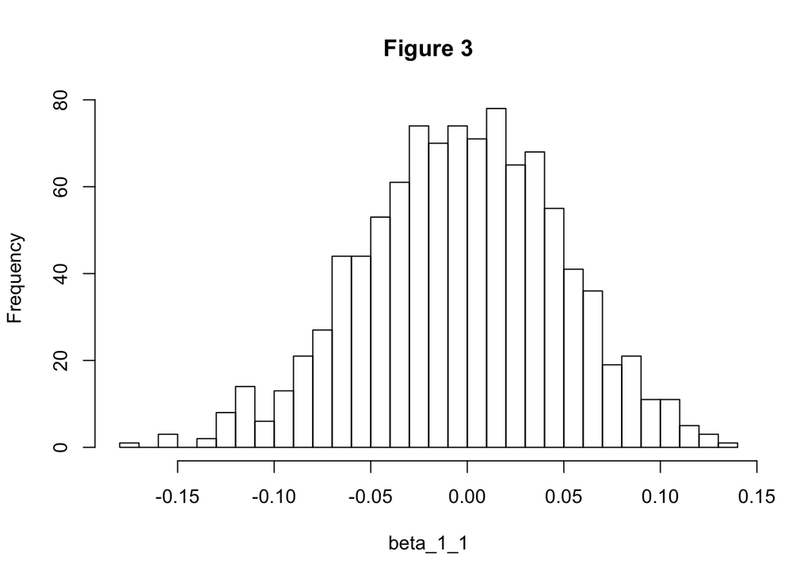

```r
x1 <- rnorm(100000, 10, 10)
u1 <- rnorm(100000, 0, 50)
y1 = 2.5 + 1.5 * x + u
situation_1 <- data.frame(x1, u1, y1)
beta_1_vector1 <- c()
for(i in 1:1000) {
  newPop1 <- situation_1[sample(nrow(situation_1), 1000), ]
  beta_1_1 <- cov(newPop1$y, newPop1$x) / var(newPop1$x)
  beta_1_vector1 <- c(beta_1_vector1, beta_1_1)
}
hist(beta_1_vector1, main = "Figure 3", xlab = "beta_1_1", breaks = 30)
```

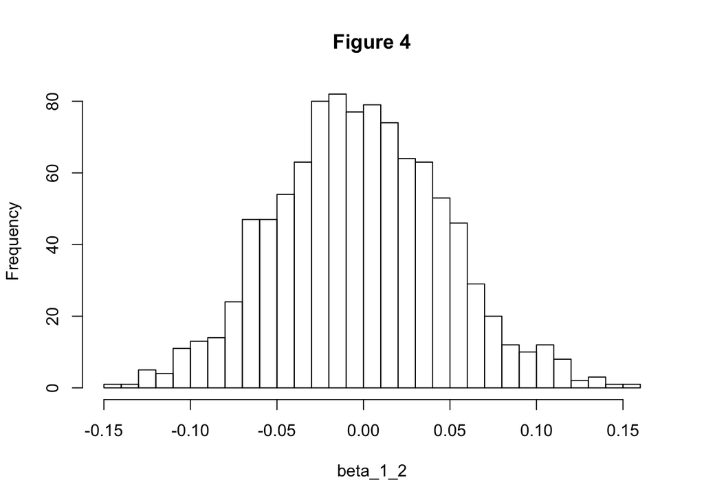

```r
x2 <- rnorm(100000, 10, 10)
u2 <- rnorm(100000, 0, 1)
y2 = 2.5 + 1.5 * x + u
situation_2 <- data.frame(x2, u2, y2)
beta_1_vector2 <- c()
for(i in 1:1000) {
  newPop2 <- situation_2[sample(nrow(situation_2), 1000), ]
  beta_1_2 <- cov(newPop2$y, newPop2$x) / var(newPop2$x)
  beta_1_vector2 <- c(beta_1_vector2, beta_1_2)
}
hist(beta_1_vector2, main = "Figure 4", xlab = "beta_1_2", breaks = 30)
```